# GLM para dados categóricos

Samuel Lima & Niege Félix

# 1 Introdução

Carregando pacotes a serem utilizados e importando o banco de dados

```r
library(VGAM) #Modelo multinomial
library(ggplot2)
library(dplyr)
library(forcats)

dados <- readRDS("../Dados/palmerpenguins_extended.rds")
```

Exercitaremos aqui o GLM para dados categóricos utilizando o modelo multinomial, que é preciso quando nossa variável resposta tem mais de duas categorias. Para isso, vamos utilizar os dados dos pinguins de Palmer, armazenados no diretório `/Dados` da disciplina.

> Nosso **objetivo** será testar se a saúde dos pinguins é influenciada por seus estágios de vida. E nossa **hipótese** é que os pinguins em seus primeiros estágios de vida são mais saudáveis.

# 2 Análise exploratória

Vamos iniciar conhecendo nossos dados:

```r
head(dados)
```

```
##   species island bill_length_mm bill_depth_mm flipper_length_mm body_mass_g
## 1  Adelie Biscoe           53.4          17.8               219        5687
## 2  Adelie Biscoe           49.3          18.1               245        6811
## 3  Adelie Biscoe           55.7          16.6               226        5388
## 4  Adelie Biscoe           38.0          15.6               221        6262
## 5  Adelie Biscoe           60.7          17.9               177        4811
## 6  Adelie Biscoe           35.7          16.8               194        5266
##      sex diet life_stage health_metrics year
## 1 female fish      adult     overweight 2021
## 2 female fish      adult     overweight 2021
## 3 female fish      adult     overweight 2021
## 4 female fish      adult     overweight 2021
## 5 female fish   juvenile     overweight 2021
## 6 female fish   juvenile     overweight 2021
```

```r
str(dados)
```

```
## 'data.frame':    3430 obs. of  11 variables:
##  $ species          : chr  "Adelie" "Adelie" "Adelie" "Adelie" ...
##  $ island           : chr  "Biscoe" "Biscoe" "Biscoe" "Biscoe" ...
##  $ bill_length_mm   : num  53.4 49.3 55.7 38 60.7 35.7 61 66.1 61.4 54.9 ...
##  $ bill_depth_mm    : num  17.8 18.1 16.6 15.6 17.9 16.8 20.8 20.8 19.9 22.3 ...
##  $ flipper_length_mm: num  219 245 226 221 177 194 211 246 270 230 ...
##  $ body_mass_g      : num  5687 6811 5388 6262 4811 ...
##  $ sex              : chr  "female" "female" "female" "female" ...
##  $ diet             : chr  "fish" "fish" "fish" "fish" ...
##  $ life_stage       : chr  "adult" "adult" "adult" "adult" ...
##  $ health_metrics   : chr  "overweight" "overweight" "overweight" "overweight" ...
##  $ year             : int  2021 2021 2021 2021 2021 2021 2021 2021 2021 2021 ...
```

Transformando as variáveis `chr` em `factor`

```r
cols <- c("species", "island", "sex", "diet", "life_stage", "health_metrics")
dados[, cols] <- lapply(dados[, cols], factor)
```

Observando valores brutos:

```r
#Quantos pinguins pintinhos por categoria de saúde
dados_chick <- dados %>% filter(life_stage=="chick")
summary(dados_chick$health_metrics)
```

```
##     healthy  overweight underweight
##         544         163         153
```

```r
#Quantos pinguins adultos por categoria de saúde
dados_adult <- dados %>% filter(life_stage=="adult")
summary(dados_adult$health_metrics)
```

```
##     healthy  overweight underweight
##         362         484         183
```

## 2.1 Observando tendências para nossa variável resposta

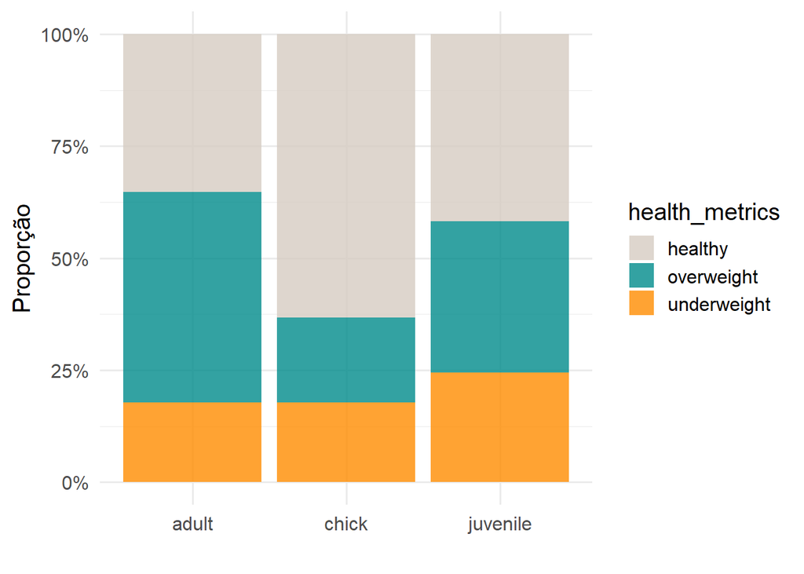

```r
ggplot(dados, aes(x = life_stage, fill = health_metrics)) +
  geom_bar(position = "fill",  alpha = 0.8) +
  scale_y_continuous(labels = scales::percent) +
  scale_fill_manual(values = c("#d6ccc2","cyan4", "darkorange")) +
  labs(y = "Proporção", x = "")+
  theme_minimal(base_size = 15)
```

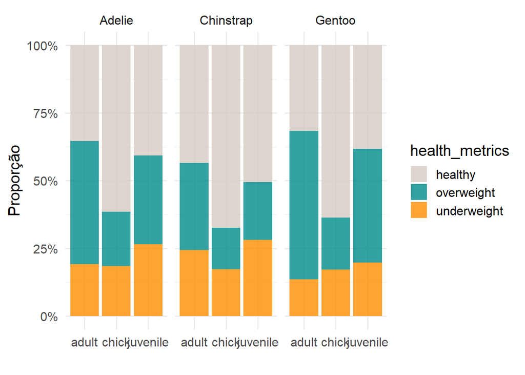

```r
ggplot(dados, aes(x = life_stage, fill = health_metrics)) +
  geom_bar(position = "fill",  alpha = 0.8) +
  scale_y_continuous(labels = scales::percent) +
  scale_fill_manual(values = c("#d6ccc2","cyan4", "darkorange")) +
  labs(y = "Proporção", x = "") +
  facet_wrap(species ~ .) +
  theme_minimal(base_size = 15)
```

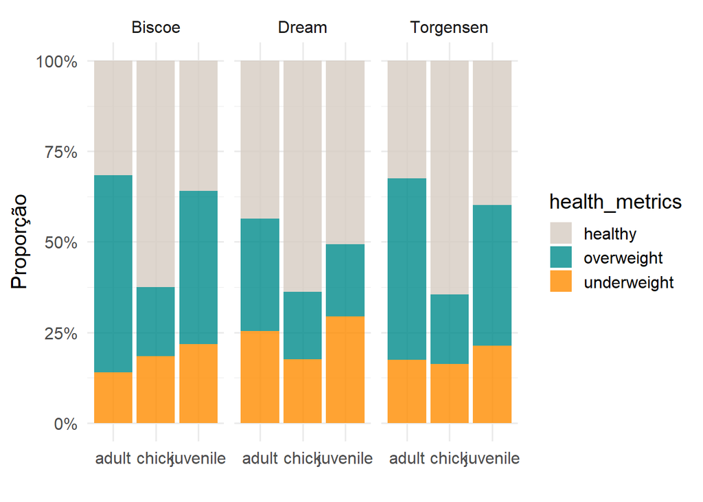

```r
ggplot(dados, aes(x = life_stage, fill = health_metrics)) +
  geom_bar(position = "fill",  alpha = 0.8) +
  scale_y_continuous(labels = scales::percent) +
  scale_fill_manual(values = c("#d6ccc2","cyan4", "darkorange")) +
  labs(y = "Proporção", x = "") +
  facet_wrap(island ~ .) +
  theme_minimal(base_size = 15)
```

Os pinguins são mais saudáveis no estágio de pintinho para as três espécies e nas três ilhas

Como estamos trabalhando com variáveis categóricas, não precisamos verificar outliers.

# 3 Metodologia

Para testar se a saúde dos pinguins é influenciada por seus estágios de vida, vamos utilizar um modelo multinomial nominal, visto que nossa variável resposta (*health_metrics*) é categórica (saudáveis, acima do peso e abaixo do peso) e não é hierárquica.

O modelo multinomial pode ser descrito conforme:

$$\large Y \sim Multinomial(n,
\mathbf{p)}$$

Onde $n$ é numéro de amostras (no nosso caso, pinguins) e $\mathbf{p}$ é a probabilidade de cada categoria ${(p_1+p_2,...,p_k)}$

O modelo multinomial permite que informemos uma categoria de referência que vai ser comparada com as demais no output do modelo (o default é a primeira categoria). As probabilidades de cada categoria é dada pelas fórmulas:

**Probabilidade da categoria de referência**

$$\large p_1 =
\frac{1}{1+\sum_{j=2}^{K}\text{exp}(\eta_j)}$$

**Probabilidade das demais categorias**

$$\large p_k =
\frac{\text{exp}(\eta_k)}{1+\sum_{j=2}^{K}\text{exp}(\eta_j)}$$

# 4 Resultados

```r
## Observando a ordem dos fatores da nossa variável resposta
levels(dados$health_metrics)
```

```
## [1] "healthy"     "overweight"  "underweight"
```

```r
modelo_1 <- vglm(health_metrics ~ life_stage,
                family = multinomial(refLevel = 1),
                data = dados)

summary(modelo_1)
```

```
##
## Call:
## vglm(formula = health_metrics ~ life_stage, family = multinomial(refLevel = 1),
##     data = dados)
##
## Coefficients:
##                      Estimate Std. Error z value Pr(>|z|)
## (Intercept):1         0.29044    0.06949   4.180 2.92e-05 ***
## (Intercept):2        -0.68216    0.09070  -7.521 5.44e-14 ***
## life_stagechick:1    -1.49564    0.11314 -13.219  < 2e-16 ***
## life_stagechick:2    -0.58635    0.12885  -4.551 5.34e-06 ***
## life_stagejuvenile:1 -0.50431    0.09113  -5.534 3.13e-08 ***
## life_stagejuvenile:2  0.14670    0.11150   1.316    0.188
## ---
## Signif. codes:  0 '***' 0.001 '**' 0.01 '*' 0.05 '.' 0.1 ' ' 1
##
## Names of linear predictors: log(mu[,2]/mu[,1]), log(mu[,3]/mu[,1])
##
## Residual deviance: 7002.468 on 6854 degrees of freedom
##
## Log-likelihood: -3501.234 on 6854 degrees of freedom
##
## Number of Fisher scoring iterations: 4
##
## No Hauck-Donner effect found in any of the estimates
##
##
## Reference group is level  1  of the response
```

Aqui nossa referência é um pinguim adulto e saudável.

Os números 1 e 2 representam as categorias logo após a referência (acima do peso e abaixo do peso, nesse modelo).

Agora vamos visualizar as predições das probabilidades para cada estágio de vida:

## 4.1 Visualizando probabilidades

```r
dados_pred2 <- data.frame(life_stage = levels(dados$life_stage))
#Primeiro nível tem que coincidir com o primeiro nível do modelo
preds2 <- predict(modelo_1,
                  newdata = dados_pred2,
                  type = "response") %>% data.frame()

preds2
```

```
##     healthy overweight underweight
## 1 0.3517979  0.4703596   0.1778426
## 2 0.6325581  0.1895349   0.1779070
## 3 0.4179104  0.3374432   0.2446463
```

> Corroboramos nossa hipótese inicial!

Ainda podemos visualizar as probabilidades em gráfico. Para fazer isso utilizando a função ggplot é preciso fazer algumas alterações..

```r
# Renomear as colunas, assumindo a mesma ordem do modelo
preds2$life_stage <- dados_pred2$life_stage

colnames(preds2) <- c("healthy","overweight","underweight","life_stage")

# Transformar dado para o formato longo
preds2l <- preds2 %>%
  tidyr::pivot_longer(cols = c("healthy","overweight","underweight"),
                      names_to = "health_metrics",
                      values_to = "Probability")


preds2l
```

```
## # A tibble: 9 × 3
##   life_stage health_metrics Probability
##   <chr>      <chr>                <dbl>
## 1 adult      healthy              0.352
## 2 adult      overweight           0.470
## 3 adult      underweight          0.178
## 4 chick      healthy              0.633
## 5 chick      overweight           0.190
## 6 chick      underweight          0.178
## 7 juvenile   healthy              0.418
## 8 juvenile   overweight           0.337
## 9 juvenile   underweight          0.245
```

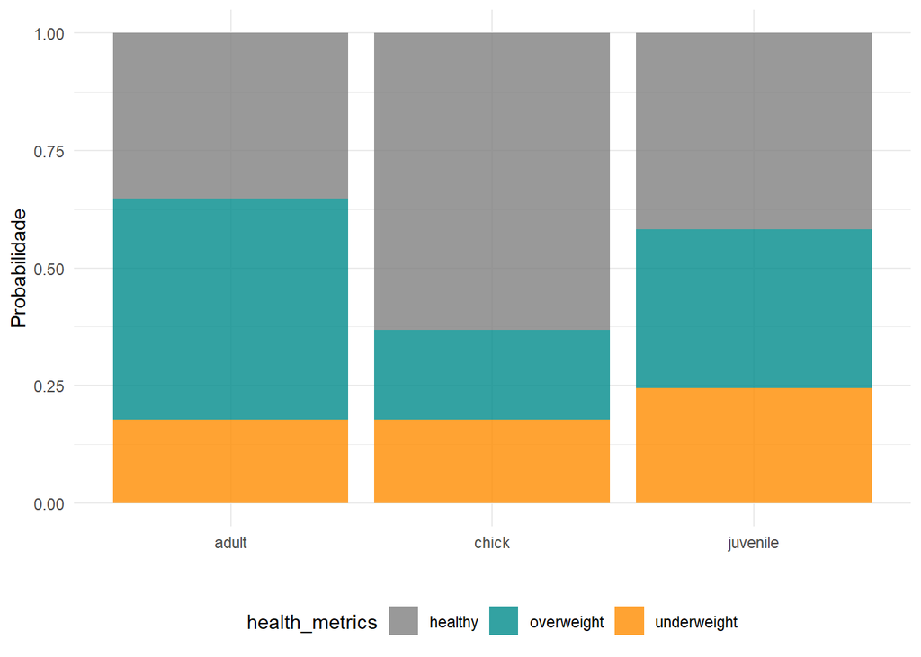

```r
#Dessa forma, podemos finalmente plotar o gráfico com as probabilidades

### Plotando....
ggplot(preds2l, aes(x = life_stage, y = Probability, fill = health_metrics)) +
  geom_bar(stat = "identity", position = "stack",  alpha = 0.8) +
  scale_fill_manual(values = c("healthy" = "gray50","overweight" = "cyan4",
                               "underweight"="darkorange")) +
  labs(y = "Probabilidade",
       x = "",
       fill = "health_metrics") +
  theme_minimal() +
  theme(legend.position = "bottom")
```